# Tutorium 3

Gruppen 5 und 7  
Samuel Teuber  
propa@teuber.dev  
https://teuber.dev/propa

# Übungsblätter

- Blatt 1 Aufgaben 2 und 3 vollständig korrigiert und veröffentlicht
- Next up: Blatt 1 Aufgabe 1 und Blatt 2  
  Digital in den nächsten Tagen, handschriftlich nächste Woche
- **Fragen? Probleme?** (Praktomat?)

**Wenn es sich irgend vermeiden lässt: Bitte keine handschriftlichen Code-Abgaben**

# Vorbemerkung 0

Haskell ist **anders**, aber **lasst euch davon nicht verwirren!**

1. Problem lesen
2. Algorithmus überlegen/nachschauen
3. Evtl. Pseudocode
4. Wie implementiere ich **diesen Mechanismus** in Haskell?

**Mergesort, Horner-Schema:** Nutzt die Algorithmen, die angegeben sind!

# Vorbemerkung 1

```
f (x:xs) a
    | a = [x]
    | otherwise = x:xs
```

Wie kann man das schöner schreiben?

Zwei Optimierungsmöglichkeiten:

```
f (x:xs) True = [x]
f l False = l
```

...oder...

```
f l@(x:xs) a
    | a = [x]
    | otherwise = l
```

```haskell
f l@(x:xs) a
    | a = [x]
    | otherwise = l
f [1,2,3] True
f [1,2,3] False
```

```
[1]
```

```
[1,2,3]
```

# Vorbemerkung 2

Wie kann ich das folgende Codestück kürzer schreiben:

```
cmult p n = map (\x -> x*n) p
```

**Currying!**

```
cmult p n = map (*n) p
```

# Vorbemerkung 3

Wie können wir folgende Ausdrücke eleganter schreiben:

```haskell
take 10 (iterate (+1) 0)
take 10 (iterate (+2) 0)
takeWhile (<=10) (iterate (+2) 0)
```

```
[0,1,2,3,4,5,6,7,8,9]
```

```
[0,2,4,6,8,10,12,14,16,18]
```

```
[0,2,4,6,8,10]
```

```haskell
take 10 [0..]
take 10 [0,2..]
[0,2..10]
```

```
[0,1,2,3,4,5,6,7,8,9]
```

```
[0,2,4,6,8,10,12,14,16,18]
```

```
[0,2,4,6,8,10]
```

# Vorbemerkung 4: Endrekursion

- **Wiederholung:** Wann ist etwas endrekursiv?
- Wann Endrekursion nutzen?

# Übungsblatt 2 - 1

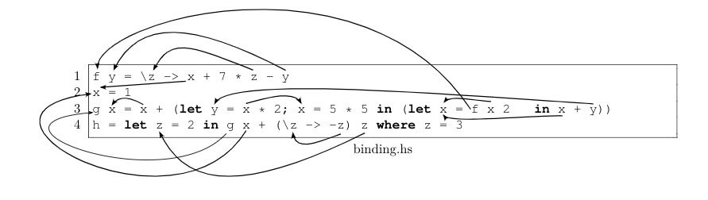

# Übungsblatt 2 - 2

`a -> a`

```
\x -> x
```

`(a -> b) -> a -> b`

```
\x -> x
```

`(a -> b) -> (a -> b)`

```
\x -> x
```

`a -> b -> a`

```
\x y -> x
```

**Alle** wohldefinierten, semantisch unterschiedlichen Funktionen des Typs  
`a -> a -> a`

```
\x y -> x
```

```
\x y -> y
```

Leere Liste vom Typ `[a]`

```
[]
```

Einelementige Liste vom Typ `[Int]`

```
[42]
```

Leere Liste vom Typ `[[a]]`

```
[]
```

Liste vom Typ `[[a]]`, die nur die *leere Liste* enthält.

```
[[]]
```

Warum gibt es keinen Wert, der für alle Typen `a` eine einelementige Liste von Typ `[a]` darstellt?

Enthaltener Wert? Es gibt kein `null` in Haskell

Gibt es einen Wert, der für alle Typen `a` eine einelementige Liste vom Type `[[a]]` darstellt?

Ja, nämlich:

```
[[]]
```

Geben Sie den Wert von `[[[[[[[[[[[a]]]]]]]]]]]` mit der kürzesten Schreibweise an

```
[]
```

# Übungsblatt 2 - 3

```
type Polynom = [Double]
```

- Polynom Multiplikation mit Konstante

  ```
  cmult :: Polynom -> Double -> Polynom
  cmult p c = map (*c) p
  ```

- Polynom Auswertung mit dem Horner Schema
  $$ a_0 + x * (a_1 + x * (a_2 + \dots (a_{n-1} + x * a_n) \dots) ) $$

  ```
  eval :: Polynom -> Double -> Double
  eval p x = foldr (\a v -> a + v*x) 0 p
  ```

- Ableitung

  ```
  deriv :: Polynom -> Polynom
  deriv [] = []
  deriv p  =zipWith (*) [1..] (tail p)
  ```

# Typen

...schon wieder...

- Jeder Ausdruck in Haskell hat einen Typ
- Haskell ist damit statisch typisiert
- Jeder Ausdruck wertet zu Werten des jeweiligen Typs aus
- Typen werden **automatisch inferiert**

# Polymorphe Typen

**Beispiel:** Listen-Typ

- `[t]` ist der Typ von Listen mit Elementen vom Typ `t`
- *Typvariable* `t` beliebig

**Sichtweisen:**

- Typvariablen parametrisieren polymorphe Typen
- Typkonstruktoren wie `[ ]` erzeugen neue Typen aus bestehenden

**Vergleichbares in Java:** Generics

```
LinkedList<T>
```

## Funktionstypen

... sind polymorph, denn...

```
s -> t
```

... beschreibt den Typ aller Funktionen von `s` nach `t` (`s`,`t` beliebig)

# Tupel

...sind polymorph, denn...

```
(,) :: s -> t -> (s,t)
```

...und umgekehrt...

```
fst :: (s,t) -> s
snd :: (s,t) -> t
```

# Typsynonyme

Verbessert die Lesbarkeit:

```
type Polynom = [Double]
```

# Explizite Typisierung

...kennen wir auch schon...

```
foldr :: (a -> b -> b) -> b -> [a] -> b
```

- Übersichtlichkeit
- Hilft beim Debugging

# Übungsaufgaben zu Streams

# Pseudozufallszahlen

$$ x_{i+1} = (a*x_i + b) mod m $$

Definiere `rand :: [Integer]` mit $$ m = 2^{16}, a = 25173, b = 13849, x_0 = 32 $$

```haskell
-- Übungsaufgabe 3
a = 25173
b = 13849
rand = iterate (\x -> (a*x + b) `mod` (2^16)) 32
rand' = 32 : map (\x -> (a*x + b) `mod` (2^16)) rand'
```

```haskell
take 10 rand
take 10 rand'
```

```
[32,32953,50566,6039,55612,20229,23746,18051,50584,401]
```

```
[32,32953,50566,6039,55612,20229,23746,18051,50584,401]
```

# Fairer Münzwurf

Wir nutzen `rand` weiter Prozedur für fairen Münzwurf von **Neumann**:

```haskell
-- Übungsaufgabe 4
neumann :: [Bool]
unfairCoin = (map (\x -> x < 2^15) rand)
neumann = neumannHelper unfairCoin
    where neumannHelper (x:y:xs)
            | x==y = neumannHelper xs
            | otherwise = x : neumannHelper xs
```

Redundant bracket

Found:

(map (\ x -> x < 2 ^ 15) rand)

Why Not:

map (\ x -> x < 2 ^ 15) rand

```haskell
take 10 neumann
```

```
[True,False,False,False,True,False,True,False,True,True]
```

# Fairness Check

Wir zählen die Menge an Köpfen und Zahlen in den ersten $n$ Münzwürfen...

```haskell
-- Übungsaufgabe 5
coinRatio :: Int -> Double
coinRatio n = count / ((fromIntegral n) - count)
    where count = fromIntegral (length (filter id (take n neumann)))

coinRatio 1000000
```

Redundant bracket

Found:

(fromIntegral n) - count

Why Not:

fromIntegral n - count

```
1.000040000800016
```

```haskell
:t (/)
:t div
```

(/) :: forall a. Fractional a => a -> a -> a

div :: forall a. Integral a => a -> a -> a

# Lauflängen Kodierung

```haskell
splitWhen p [] = ([],[])
splitWhen p l@(x:xs)
    | p x = ([],l)
    | otherwise = let (l1, l2) = splitWhen p xs in (x:l1, l2)

input = "aaaaaaabbbbbbccceeeedaaaaaabbbe"

splitWhen (/='a') input

runlength :: String -> [(Char, Int)]
runlength [] = []
runlength l@(x:xs) = (x, length a) : (runlength b)
    where
        (a,b) = splitWhen (/=x) l
        asdf x
         |x = 1
         | otherwise = 2

runlength input

repeat' (c,0) = []
repeat' (c,n) = c : repeat' (c, (n-1))
repeat' ('a',4)

decode [] = ""
decode (x:xs) = (repeat' x) ++ (decode xs)

decode (runlength input)
```

Redundant bracket

Found:

(x, length a) : (runlength b)

Why Not:

(x, length a) : runlength b

Redundant bracket

Found:

(c, (n - 1))

Why Not:

(c, n - 1)

Use foldr

Found:

decode [] = "" decode (x : xs) = (repeat' x) ++ (decode xs)

Why Not:

decode xs = foldr ((++) . repeat') "" xs

Redundant bracket

Found:

(repeat' x) ++ (decode xs)

Why Not:

repeat' x ++ (decode xs)

Redundant bracket

Found:

(repeat' x) ++ (decode xs)

Why Not:

(repeat' x) ++ decode xs

```
("aaaaaaa","bbbbbbccceeeedaaaaaabbbe")
```

```
[('a',7),('b',6),('c',3),('e',4),('d',1),('a',6),('b',3),('e',1)]
```

```
"aaaa"
```

```
"aaaaaaabbbbbbccceeeedaaaaaabbbe"
```